# GAM meta analysis data exploration

Kimberly Bastille

6/22/2022

# Background

Below is a summary of the data comparisons between the Beck et. al 2022 paper and the NERRS data. Their analysis consisted of 3 steps. 1) Ran a gam analysis on the biweekly/monthly samples to estimate a smooth temporal pattern. 2) Used the smoothed gam to get a daily timeseries. 3) Took seasonal estimate averages from the daily times series. The goal of this is to propogate uncertainty through the analysis.

They used that estimates to evaluate linear trends over a moving average through different time periods (10 years). They interpreted the slope of the regression a representative for the central year in the moving avg block. Our timeseries is only 12 years so a 4yr moving window was used to get three distinct blocks like the Beck paper.

# Data Summary

[output not shown]

Data only presented for Wells Bay, Maine and Waquoit Bay, Massachusetts because these stations had the fewest years missing.

# GAM meta analysis

## Wells Bay (Data Rich)

### Timeseries GAM

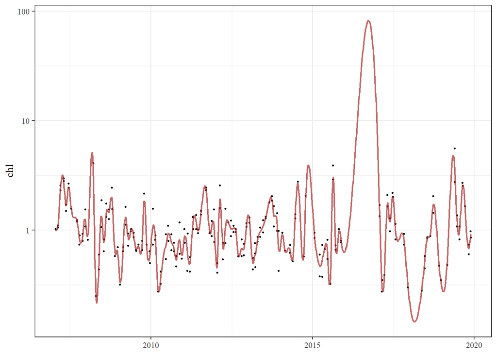

### Monthly

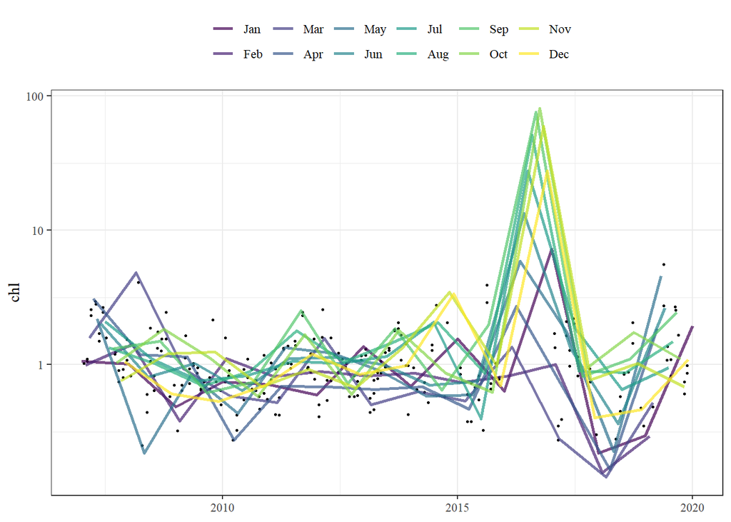

### DOY

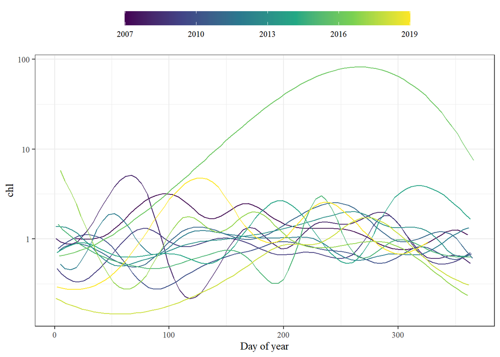

### Summer seasonal average with regression

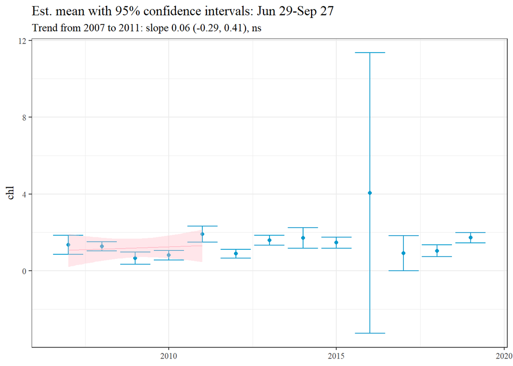

### Summer seasonal average log slopes (window = 4)

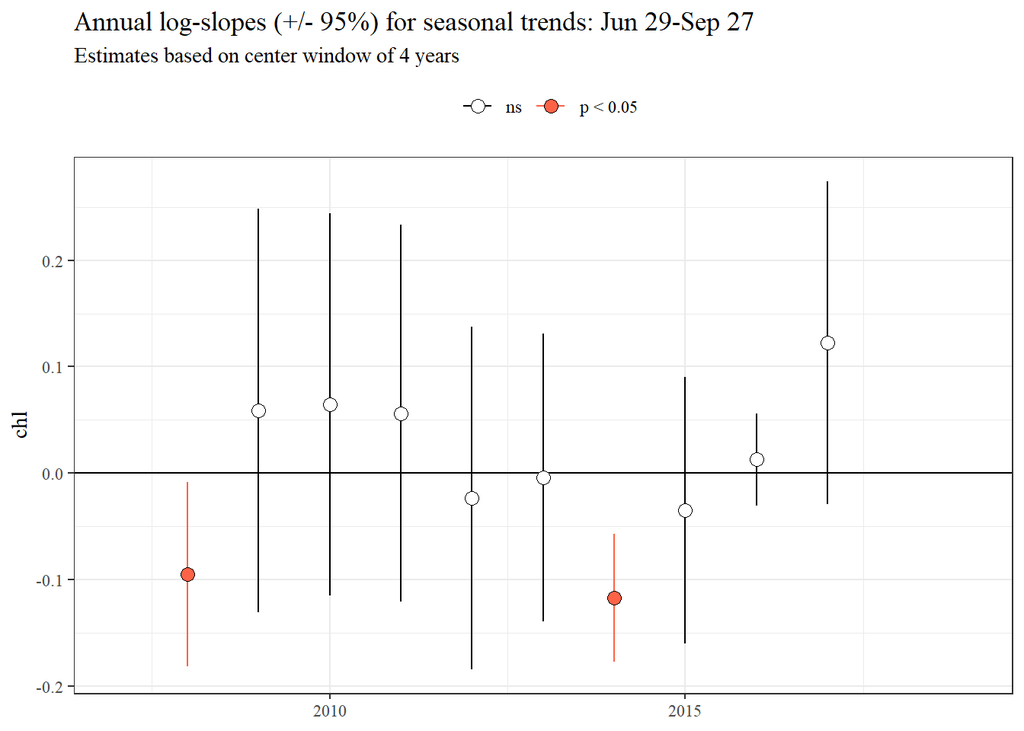

## Waquoit (Data Poor)

### Timeseries GAM

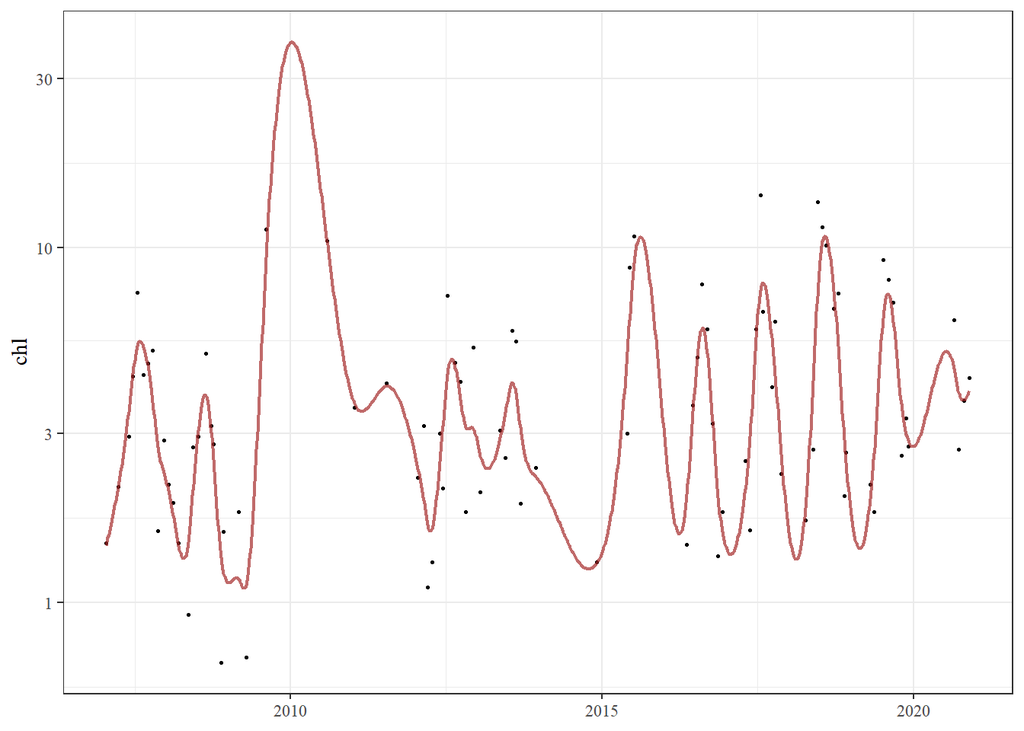

### Monthly

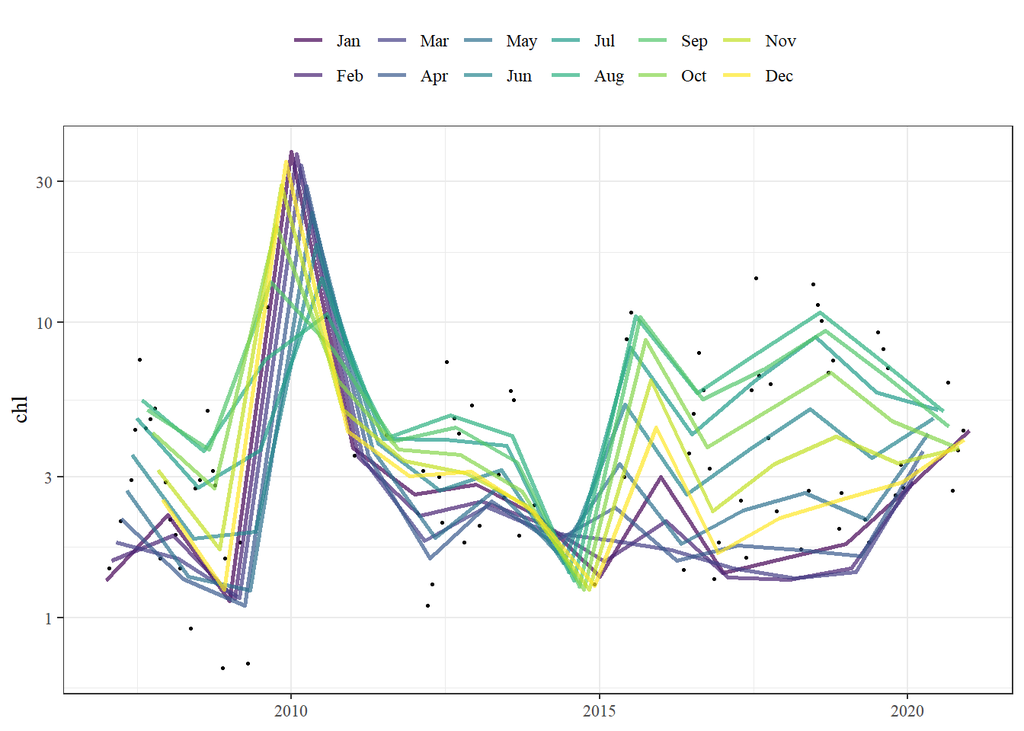

### DOY

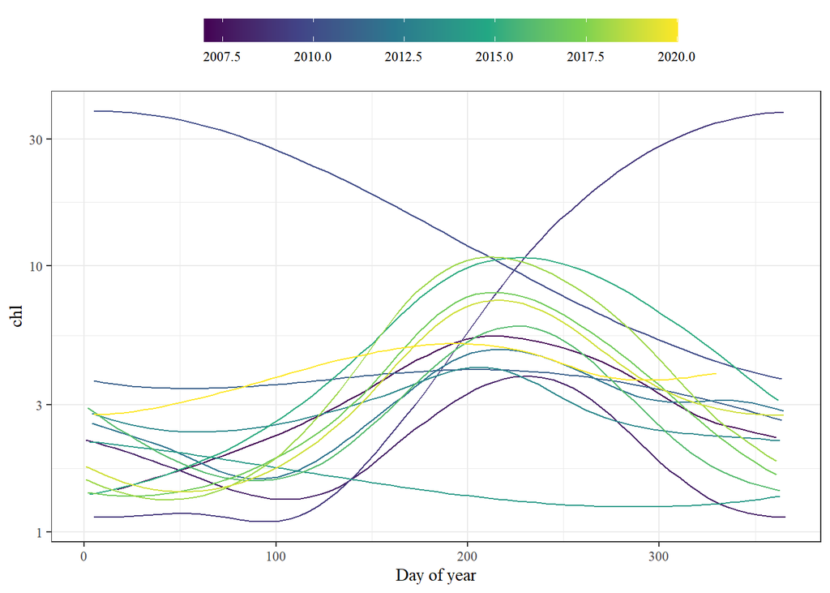

### Summer seasonal average with regression

[output not shown]

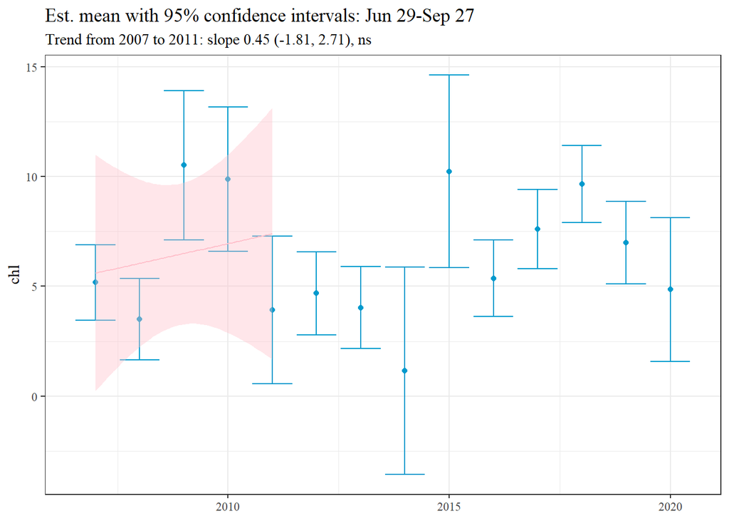

### Summer seasonal average log slopes (window = 4)

[output not shown]

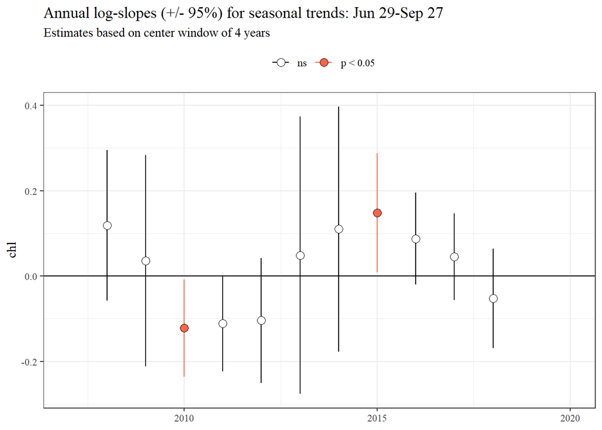